# Lab 5 - Data Cleaning and EDA

Nguyễn Thị Kiều Trang - 24133064

23/05/26

Trong bài lab này ta sẽ sử dụng thư viện `tidyr`, `dplyr` và `ggplot2` để làm sạch, thao tác, và trực quan hóa dữ liệu.

### Dữ liệu

- Dữ liệu cho bài lab được lấy từ trang web gapminder (https://www.gapminder.org/data/). Có 4 file dữ liệu (.csv) chứa thông tin về quốc gia, châu lục (`country_continent.csv`), dân số (`population_total.csv`), thu nhập (`life_expectancy_years.csv`), và gpd (`income_per_person_gdppercapita_ppp_inflation_adjusted.csv`). Bạn cần tổng hợp thông tin từ các file này dùng thư viện `tidyr` để tạo thành một data frame thống nhất gồm các thuộc tính sau:
- `country`: quốc gia
- `continent`: châu lục
- `year`: năm thống kê
- `lifeExp`: tuổi thọ trung bình
- `pop`: dân số
- `gdpPercap`: gpd bình quân đầu người (đã điều chỉnh theo lạm phát)

Đầu tiên, bạn cần load thư viện `tidyverse`.

```r
library(tidyverse)
```

Tiếp theo, bạn cần load dữ liệu từ các file `.csv`. Các đoạn mã sau sẽ load các file dữ liệu này và in ra vài dòng đầu tiên.

```r
country <- read.csv("country_continent.csv", header = T)
head(country)
```

```
##            country continent
## 1          Nigeria    Africa
## 2            Egypt    Africa
## 3         Ethiopia    Africa
## 4 Congo, Dem. Rep.    Africa
## 5     South Africa    Africa
## 6            Sudan    Africa
```

```r
pop <- read.csv("population_total.csv", header = T)
head(pop[,1:8])
```

```
##                country X1800 X1801 X1802 X1803 X1804 X1805 X1806
## 1          Afghanistan 3.28M 3.28M 3.28M 3.28M 3.28M 3.28M 3.28M
## 2               Angola 1.57M 1.57M 1.57M 1.57M 1.57M 1.57M 1.57M
## 3              Albania  400k  402k  404k  405k  407k  409k  411k
## 4              Andorra  2650  2650  2650  2650  2650  2650  2650
## 5 United Arab Emirates 40.2k 40.2k 40.2k 40.2k 40.2k 40.2k 40.2k
## 6            Argentina  534k  520k  506k  492k  479k  466k  453k
```

```r
lifeExp <- read.csv("life_expectancy_years.csv", header = T)
head(lifeExp)
```

```
##                country X1800 X1801 X1802 X1803 X1804 X1805 X1806 X1807 X1808
## 1          Afghanistan  28.2  28.2  28.2  28.2  28.2  28.2  28.1  28.1  28.1
## 2               Angola  27.0  27.0  27.0  27.0  27.0  27.0  27.0  27.0  27.0
## 3              Albania  35.4  35.4  35.4  35.4  35.4  35.4  35.4  35.4  35.4
## 4              Andorra    NA    NA    NA    NA    NA    NA    NA    NA    NA
## 5 United Arab Emirates  30.7  30.7  30.7  30.7  30.7  30.7  30.7  30.7  30.7
## 6            Argentina  33.2  33.2  33.2  33.2  33.2  33.2  33.2  33.2  33.2
##   X1809 X1810 X1811 X1812 X1813 X1814 X1815 X1816 X1817 X1818 X1819 X1820 X1821
## 1  28.1  28.1  28.1  28.1  28.1  28.1  28.1  28.1  28.0  28.0  28.0  28.0  28.0
## 2  27.0  27.0  27.0  27.0  27.0  27.0  27.0  27.0  27.0  27.0  27.0  27.0  27.0
## 3  35.4  35.4  35.4  35.4  35.4  35.4  35.4  35.4  35.4  35.4  35.4  35.4  35.4
## 4    NA    NA    NA    NA    NA    NA    NA    NA    NA    NA    NA    NA    NA
## 5  30.7  30.7  30.7  30.7  30.7  30.7  30.7  30.7  30.7  30.7  30.7  30.7  30.7
## 6  33.2  33.2  33.2  33.2  33.2  33.2  33.2  33.2  33.2  33.2  33.2  33.2  33.2
##   X1822 X1823 X1824 X1825 X1826 X1827 X1828 X1829 X1830 X1831 X1832 X1833 X1834
```

[output cut: 153 more lines]

```r
gdpPercap <- read.csv("income_per_person_gdppercapita_ppp_inflation_adjusted.csv", header = T)
head(gdpPercap[,1:8])
```

```
##                country X1800 X1801 X1802 X1803 X1804 X1805 X1806
## 1          Afghanistan   683   683   683   683   683   683   683
## 2               Angola   700   702   705   709   711   714   718
## 3              Albania   755   755   755   755   755   756   756
## 4              Andorra  1360  1360  1360  1360  1370  1370  1370
## 5 United Arab Emirates  1130  1130  1140  1140  1150  1150  1160
## 6            Argentina  1730  1730  1740  1740  1750  1760  1760
```

- Đoạn mã sau sẽ đổi tên cột đầu tiên ở các data frame `lifeExp`, `pop`, `gdpPercap` từ `ï..country` thành `country` cho thuận tiện trong việc thao tác.

```r
names(lifeExp)[1] <- 'country'
names(pop)[1] <- 'country'
names(gdpPercap)[1] <- 'country'

#rename(lifeExp, country = ends_with("country"))
#rename(pop, country = ends_with("country"))
#rename(gdpPercap, country = ends_with("country"))
```

## I. Làm sạch dữ liệu

### Câu 1. Chuyển dữ liệu từ dạng wide sang dạng long

- Hãy thực hiện việc chọn ra các cột “country”, và “X1920” đến “X2020” từ tất cả các data frame `lifeExp`, `pop`, và `gdpPercap`, đồng thời biến chúng từ dạng wide sang dạng long, dùng hàm `pivot_longer()` từ thư viện `tidyr`.

#### Chuyển đổi dữ liệu lifeExp

```r
lifeExp_long <- lifeExp%>%
  select(country, X1920:X2020) %>%
  pivot_longer(cols = X1920:X2020, names_to = "year", values_to = "lifeExp")
```

#### Chuyển đổi dữ liệu pop

```r
pop_long <- pop %>%
  select(country, X1920:X2020) %>%
  pivot_longer(cols = X1920:X2020, names_to = "year", values_to = "pop")
```

#### Chuyển đổi dữ liệu gdpPercap

```r
gdpPercap_long <- gdpPercap %>%
  select(country, X1920:X2020) %>%
  pivot_longer(cols = X1920:X2020, names_to = "year", values_to = "gdpPercap")
```

#### Kiểm tra

```r
head(lifeExp_long)
```

```
## # A tibble: 6 × 3
##   country     year  lifeExp
##   <chr>       <chr>   <dbl>
## 1 Afghanistan X1920    37.1
## 2 Afghanistan X1921    37.3
## 3 Afghanistan X1922    37.5
## 4 Afghanistan X1923    37.7
## 5 Afghanistan X1924    37.9
## 6 Afghanistan X1925    38.1
```

```r
head(pop_long)
```

```
## # A tibble: 6 × 3
##   country     year  pop
##   <chr>       <chr> <chr>
## 1 Afghanistan X1920 10.6M
## 2 Afghanistan X1921 10.5M
## 3 Afghanistan X1922 10.3M
## 4 Afghanistan X1923 9.71M
## 5 Afghanistan X1924 9.2M
## 6 Afghanistan X1925 8.72M
```

```r
head(gdpPercap_long)
```

```
## # A tibble: 6 × 3
##   country     year  gdpPercap
##   <chr>       <chr> <chr>
## 1 Afghanistan X1920 1200
## 2 Afghanistan X1921 1210
## 3 Afghanistan X1922 1220
## 4 Afghanistan X1923 1230
## 5 Afghanistan X1924 1240
## 6 Afghanistan X1925 1240
```

### Câu 2. Tạo data frame thống nhất từ các data frame Hãy kết các data frame đã có để tao thành data frame thống nhất tên `gap` bao gồm các thuộc tính `country`, `year`, `pop`, `lifeExp`, và `gdpPercap`. Bạn cần đổi tham số `eval=TRUE` trước khi `Knit` để tạo file `.html`.

```r
gap <- lifeExp_long %>%
  left_join(pop_long, by = c("country", "year")) %>%
  left_join(gdpPercap_long, by = c("country", "year")) %>%
  left_join(country, by = "country") %>%
  select(country, continent, year, lifeExp, pop, gdpPercap)
head(gap)
```

```
## # A tibble: 6 × 6
##   country     continent year  lifeExp pop   gdpPercap
##   <chr>       <chr>     <chr>   <dbl> <chr> <chr>
## 1 Afghanistan Asia      X1920    37.1 10.6M 1200
## 2 Afghanistan Asia      X1921    37.3 10.5M 1210
## 3 Afghanistan Asia      X1922    37.5 10.3M 1220
## 4 Afghanistan Asia      X1923    37.7 9.71M 1230
## 5 Afghanistan Asia      X1924    37.9 9.2M  1240
## 6 Afghanistan Asia      X1925    38.1 8.72M 1240
```

Tới bước này, ta đã có được data frame với các thuộc tính mong muốn. Tuy nhiên, các cột `year`, `pop`, `gdpPercap` chưa có kiểu dữ liệu phù hợp. Ta cần làm sạch dữ liệu từ các cột này.

### Câu 3. Làm sạch dữ liệu từ các cột `year`, `pop`, và `gdpPercap`

1. Viết hàm `clean_pop()` để làm sạch dữ liệu cho cột `pop`. Chú ý: giá trị `M` trong cột này đại diện cho milion (một triệu), giá trị `k` đại diện cho kilo (một nghìn), và giá trị`B` đại diện cho bilion (một tỷ). Dựa trên các giá trị này bạn cần nhân giá trị đã có với hệ số tương ứng: nhân 1 cho `M`, nhân 1000 cho `B`, và nhân 0.001 cho `k` (đơn vị là triệu dân).

```r
clean_pop <- function(x) {
# Xóa khoảng trắng nếu có
  x <- str_trim(x)

  # Tạo vector kết quả trống
  res <- numeric(length(x))

  # Lọc và tính toán theo điều kiện đề bài
  res[str_detect(x, "M$")] <- as.numeric(str_remove(x[str_detect(x, "M$")], "M")) * 1
  res[str_detect(x, "B$")] <- as.numeric(str_remove(x[str_detect(x, "B$")], "B")) * 1000
  res[str_detect(x, "k$")] <- as.numeric(str_remove(x[str_detect(x, "k$")], "k")) * 0.001

  # Trường hợp là số thuần túy không có ký tự đi kèm (chia cho 1 triệu để ra đơn vị triệu dân)
  pure_num <- !str_detect(x, "[MBk]$") & !is.na(x)
  res[pure_num] <- as.numeric(x[pure_num]) / 1000000

  return(res)
}

x = c("3.28M", "400k", "1.2B")
y = clean_pop(x)
y
```

```
## [1]    3.28    0.40 1200.00
```

2. Viết hàm `clean_year()` để làm sạch dữ liệu cho cột `year`. Dữ liệu cột này cần ở dạng số nguyên. Bạn cần xóa ký tự `X` trong giá trị năm và chuyển nó về dạng số nguyên (dùng hàm `as.integer()`).

```r
clean_year <- function(x) {
  res <- str_remove(x, "^X")
  return(as.integer(res))
}

x = c("X1800", "X1801", "X1802")
y = clean_year(x)
y
```

```
## [1] 1800 1801 1802
```

3. Viết hàm `clean_gdpPercap()` để làm sạch dữ liệu cho cột `gdpPercap`. Dữ liệu cột này cần ở dạng số. Giá trị `k` đại diện cho kilo (một nghìn), do đó, các giá trị nào cho chứa `k` bạn cần nhân giá trị đã có với 1000 (đơn vị là USD).

```r
clean_gdpPercap <- function(x) {
  x <- str_trim(x)
  res <- numeric(length(x))

  has_k <- str_detect(x, "k$")
  res[has_k] <- as.numeric(str_remove(x[has_k], "k")) * 1000
  res[!has_k] <- as.numeric(x[!has_k])

  return(res)
}

x = c("328", "1.84k", "1.2k")
y = clean_gdpPercap(x)
y
```

```
## [1]  328 1840 1200
```

4. Áp dụng các hàm `clean_pop` và `clean_year()` trên các cột `pop` và `year` Làm sạch dữ liệu của các cột `pop`, `year`, và `gdpPercap` dùng các hàm `clean_pop`, `clean_year()`, và `clean_gdpPercap()` tương ứng.

```r
gap <- gap %>%
  mutate(
    pop = clean_pop(pop),
    year = clean_year(year),
    gdpPercap = clean_gdpPercap(gdpPercap)
  )
```

Kiểm tra

```r
str(gap)
```

```
## tibble [19,695 × 6] (S3: tbl_df/tbl/data.frame)
##  $ country  : chr [1:19695] "Afghanistan" "Afghanistan" "Afghanistan" "Afghanistan" ...
##  $ continent: chr [1:19695] "Asia" "Asia" "Asia" "Asia" ...
##  $ year     : int [1:19695] 1920 1921 1922 1923 1924 1925 1926 1927 1928 1929 ...
##  $ lifeExp  : num [1:19695] 37.1 37.3 37.5 37.7 37.9 38.1 38.3 38.4 38.6 38.8 ...
##  $ pop      : num [1:19695] 10.6 10.5 10.3 9.71 9.2 8.72 8.26 7.83 7.42 7.1 ...
##  $ gdpPercap: num [1:19695] 1200 1210 1220 1230 1240 1240 1250 1260 1270 1270 ...
```

```r
head(gap)
```

```
## # A tibble: 6 × 6
##   country     continent  year lifeExp   pop gdpPercap
##   <chr>       <chr>     <int>   <dbl> <dbl>     <dbl>
## 1 Afghanistan Asia       1920    37.1 10.6       1200
## 2 Afghanistan Asia       1921    37.3 10.5       1210
## 3 Afghanistan Asia       1922    37.5 10.3       1220
## 4 Afghanistan Asia       1923    37.7  9.71      1230
## 5 Afghanistan Asia       1924    37.9  9.2       1240
## 6 Afghanistan Asia       1925    38.1  8.72      1240
```

Đến đây, dữ liệu đã được làm sạch và thỏa điều kiện để là tidy data. Ta sẽ thực hiện EDA trên dữ liệu này.

## II. EDA

### Câu 1 - Tạo tập dữ liệu `gap18` cho năm 2018. Bạn cần đổi tham số `eval=TRUE` trước khi `Knit` để tạo file `.html`.

```r
gm18 <- gap %>%
  filter(year == 2018)

head(gm18)
```

```
## # A tibble: 6 × 6
##   country              continent  year lifeExp    pop gdpPercap
##   <chr>                <chr>     <int>   <dbl>  <dbl>     <dbl>
## 1 Afghanistan          Asia       2018    62.7 37.2        2030
## 2 Angola               Africa     2018    64.6 30.8        6930
## 3 Albania              Europe     2018    78.4  2.88      13300
## 4 Andorra              <NA>       2018    82.1  0.077     58300
## 5 United Arab Emirates <NA>       2018    73.7  9.63      67000
## 6 Argentina            Americas   2018    76.5 44.4       22700
```

Thực hiện các yêu cầu bên dưới dùng các package `ggplot2`, `dplyr`, và tập dữ liệu `gm18`.

### Câu 2 - geom_point

- Vẽ biểu đồ scatter thể hiện mối quan hệ giữa GDP (`gdpPercap`) và Life Expectancy (`lifeExp`) dùng tập dữ liệu `gm18`.

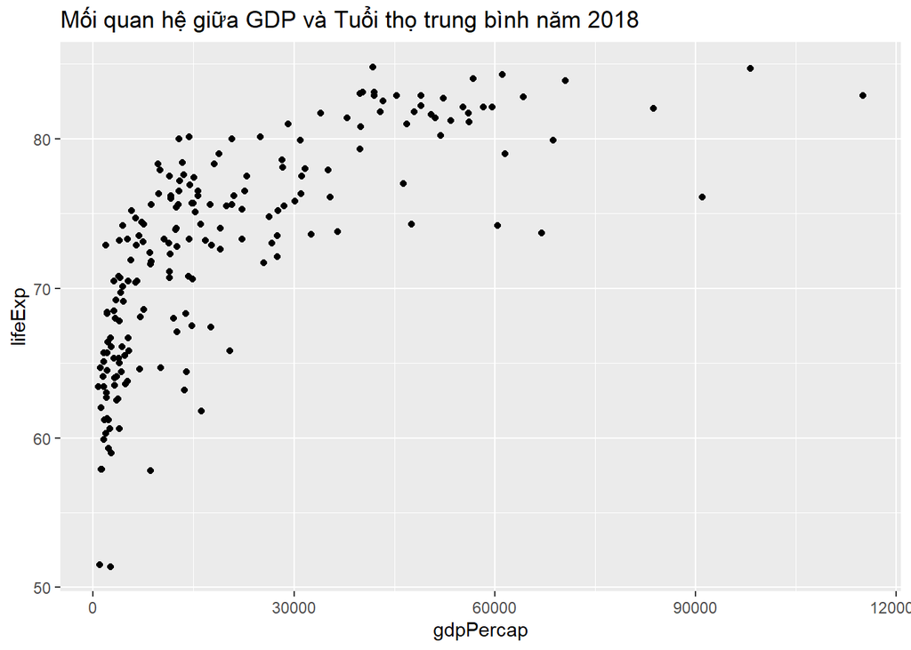

```r
ggplot(gm18, aes(x = gdpPercap, y = lifeExp)) +
  geom_point() +
  labs(
    title = "Mối quan hệ giữa GDP và Tuổi thọ trung bình năm 2018"
    )
```

```r
ggsave("BieudoGDPvalifeExp.png")
```

Biểu đồ cho thấy giữa GDP bình quân đầu người (gdpPercap) và tuổi thọ trung bình (lifeExp) tồn tại mối quan hệ cùng chiều. Khi GDP tăng thì tuổi thọ trung bình cũng có xu hướng tăng lên. Tuy nhiên, mức tăng không hoàn toàn tuyến tính: ở nhóm quốc gia có GDP thấp, tuổi thọ tăng khá nhanh khi GDP tăng; trong khi ở nhóm GDP cao, tuổi thọ có xu hướng tăng chậm lại và dần ổn định quanh mức 75–85 tuổi. Ngoài ra vẫn xuất hiện một số điểm dữ liệu nằm xa phần lớn quan sát, cho thấy có những quốc gia có GDP rất cao nhưng tuổi thọ không tăng tương ứng hoặc ngược lại.

### Câu 3 - geom_bar

- Vẽ biểu đồ bar chart thể hiện số quốc quốc gia (`country`) theo châu lục (`continent`) dùng tập dữ liệu `gm18`.

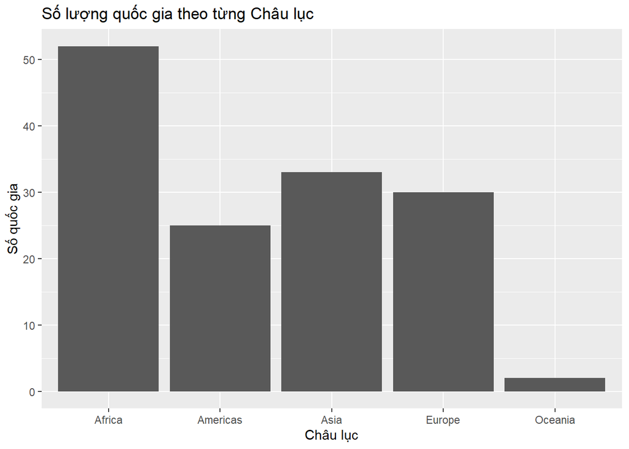

```r
country %>%
filter(!is.na(continent)) %>%
  ggplot(aes(x = continent)) +
  geom_bar(na.rm = TRUE) +
  labs(
    title = "Số lượng quốc gia theo từng Châu lục",
    x = "Châu lục",
    y = "Số quốc gia")
```

```r
ggsave("Bieudoquocgiachauluc.png")
```

Biểu đồ cột cho thấy số lượng quốc gia phân bố không đồng đều giữa các châu lục. Africa có số lượng quốc gia nhiều nhất với khoảng hơn 50 quốc gia. Tiếp theo là Asia và Europe với số lượng khá tương đương nhau, khoảng 30–35 quốc gia. Americas có số lượng thấp hơn một chút, khoảng 25 quốc gia. Oceania là khu vực có ít quốc gia nhất, chỉ khoảng 2–3 quốc gia. Điều này cho thấy dữ liệu có sự khác biệt về số lượng quan sát giữa các khu vực, trong đó châu Phi chiếm tỷ trọng lớn còn châu Đại Dương chiếm tỷ trọng nhỏ.

### Câu 4 - summarize

- Tính dân số trung bình (mean) và trung vị (median) theo châu lục dùng tập dữ liệu `gm18`.

```r
gm18 %>%
  group_by(continent) %>%
  summarise(
    pop_mean = mean(pop, na.rm = TRUE),
    pop_median = median(pop, na.rm = TRUE)
  )
```

```
## # A tibble: 6 × 3
##   continent pop_mean pop_median
##   <chr>        <dbl>      <dbl>
## 1 Africa       25.2      14.7
## 2 Americas     41.6      11.4
## 3 Asia        147.       31.5
## 4 Europe       20.5       9.3
## 5 Oceania      14.8      14.8
## 6 <NA>          7.71      0.766
```

### Câu 5 - geom_bar

- Tạo biểu đồ bar chart cho dân số trung vị (median) theo châu lục dùng tập dữ liệu `gm18`.

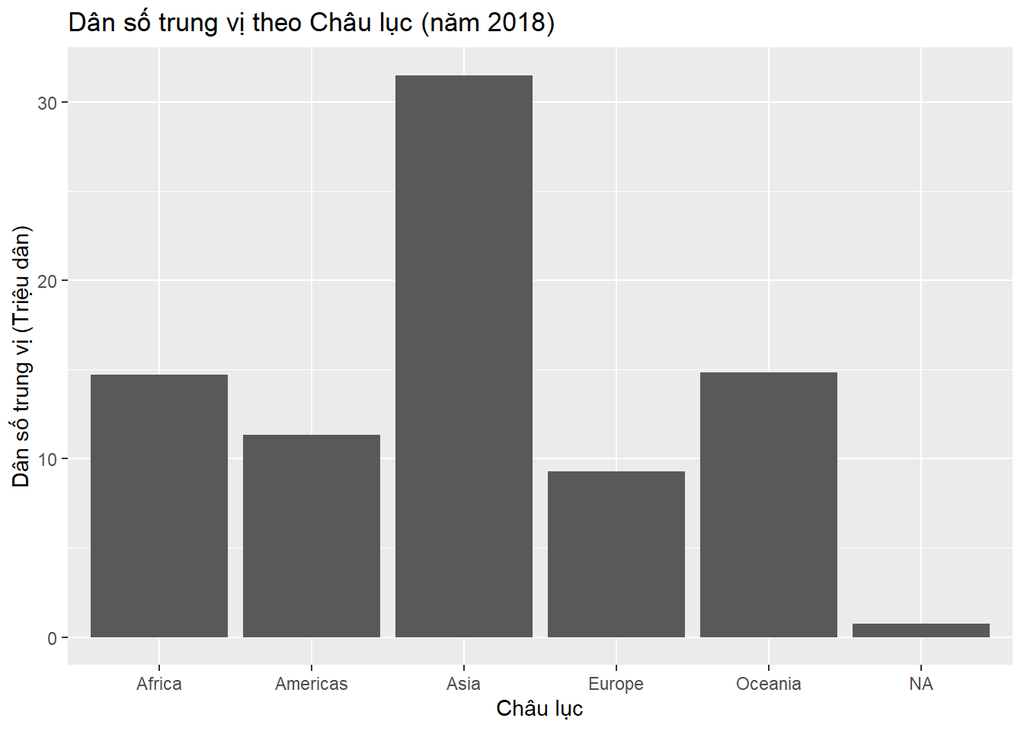

```r
gm18_summary <- gm18 %>%
  group_by(continent) %>%
  summarise(pop_median = median(pop, na.rm = TRUE))

ggplot(gm18_summary, aes(x = continent, y = pop_median)) +
  geom_col() +
  labs(title = "Dân số trung vị theo Châu lục (năm 2018)", x = "Châu lục", y = "Dân số trung vị (Triệu dân)")
```

```r
ggsave("Bieudotrungvichauluc.png")
```

### Câu 6 - labs

- Tạo biểu đồ thể hiện sự thay đổi GDP của Việt Nam theo thời gian dùng tập dữ liệu `gapminder`. Trong đó, trục `x` đặt tên là “Year”, trục `y` đặt tên là `GDP/Population`, `title` là “Vietnam’s GPD by year”. Nếu bạn cần lưu biểu đồ thành file ảnh, bạn có thể sử dụng hàm `ggsave()`.

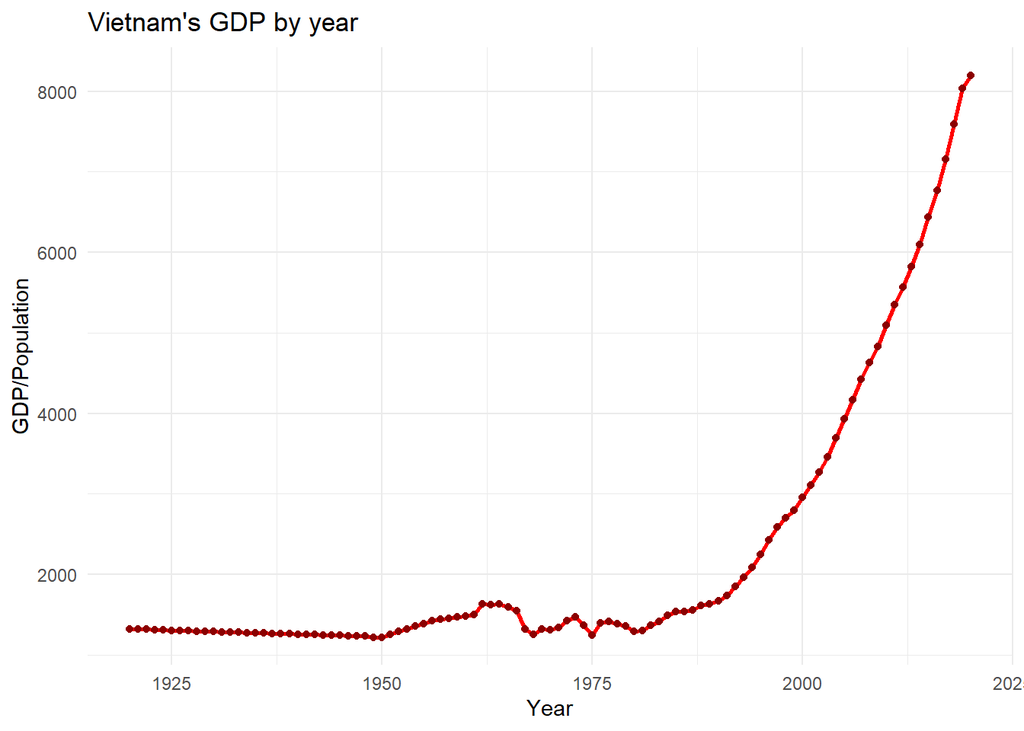

```r
vietnam_data <- gap %>%
  filter(country == "Vietnam")

ggplot(vietnam_data, aes(x = year, y = gdpPercap)) +
  geom_line(color = "red", linewidth = 1) +
  geom_point(color = "darkred") +
  labs(
    title = "Vietnam's GDP by year",
    x = "Year",
    y = "GDP/Population"
  ) +
  theme_minimal()
```

```r
ggsave("BieudoGDPVietNam.png")
```

Biểu đồ đường cho thấy GDP bình quân đầu người của Việt Nam có xu hướng tăng theo thời gian, tuy nhiên tốc độ tăng không đồng đều giữa các giai đoạn. Trong khoảng từ năm 1920 đến khoảng cuối thập niên 1980, GDP gần như biến động nhẹ và duy trì ở mức thấp, thậm chí có một số giai đoạn giảm nhẹ. Từ khoảng đầu thập niên 1990 trở đi, GDP bắt đầu tăng nhanh hơn và xu hướng tăng trở nên rõ rệt. Đặc biệt sau năm 2000, tốc độ tăng trưởng mạnh hơn rất nhiều, đường biểu diễn dốc lên rõ ràng và đạt mức cao nhất ở các năm gần đây. Điều này cho thấy nền kinh tế Việt Nam có sự phát triển mạnh trong giai đoạn hiện đại.

### Câu 7 - geom_histogram

- Tạo biểu đồ histogram thể hiện sự phân bố về dân số của các quốc gia vào năm 2018.

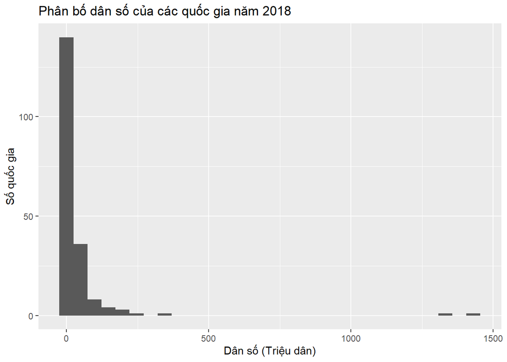

```r
ggplot(gm18, aes(x = pop)) +
  geom_histogram() +
  labs(title = "Phân bố dân số của các quốc gia năm 2018", x = "Dân số (Triệu dân)", y = "Số quốc gia")
```

```r
ggsave("Bieudodansoquocgia.png")
```

### Câu 8 - geom_histogram

- Tạo biểu đồ histogram thể hiện sự phân bố về dân số của các quốc gia vào năm 2018 nhưng bỏ đi các quốc gia có dân số quá cao hoặc quá thấp (outlier).

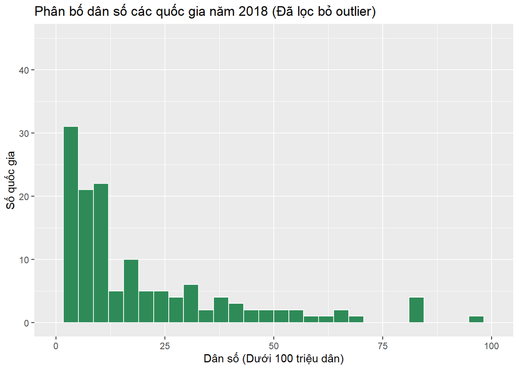

```r
ggplot(gm18, aes(x = pop)) +
  geom_histogram(fill = "seagreen", color = "white", bins = 30) +
  xlim(0, 100) +
  labs(title = "Phân bố dân số các quốc gia năm 2018 (Đã lọc bỏ outlier)", x = "Dân số (Dưới 100 triệu dân)", y = "Số quốc gia")
```

```r
ggsave("Bieudodansoquocgia2018.png")
```

### Câu 9 - geom_boxplot

- Tạo biểu đồ boxplot thể hiện sự phân bố về dân số của các quốc gia theo năm.

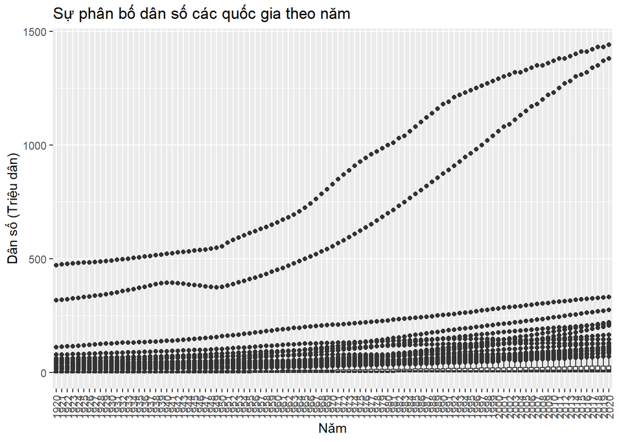

```r
ggplot(gap, aes(x = factor(year), y = pop)) +
  geom_boxplot() +
  labs(title = "Sự phân bố dân số các quốc gia theo năm", x = "Năm", y = "Dân số (Triệu dân)") +
  theme(axis.text.x = element_text(angle = 90, vjust = 0.5, hjust = 1))
```

```r
ggsave("Bieudodansoquocgia.png")
```

### Câu 10 - summarize

- Tính dân số trung bình theo châu lục và năm. Kết quả gồm 3 cột, `pop_mean`, `continent`, và `year`.

```r
pop_mean <- gap %>%
  group_by(continent, year) %>%
  summarise(
    pop_mean = mean(pop, na.rm = TRUE),
    .groups = "drop"
  )

head(pop_mean)
```

```
## # A tibble: 6 × 3
##   continent  year pop_mean
##   <chr>     <int>    <dbl>
## 1 Africa     1920     2.97
## 2 Africa     1921     3.00
## 3 Africa     1922     3.03
## 4 Africa     1923     3.06
## 5 Africa     1924     3.10
## 6 Africa     1925     3.14
```

### Câu 11 - geom_line

- Vẽ biểu đồ đường (line) thể hiện sự thay đổi của dân số trung bình của các châu lục theo năm, tô màu theo châu lục.

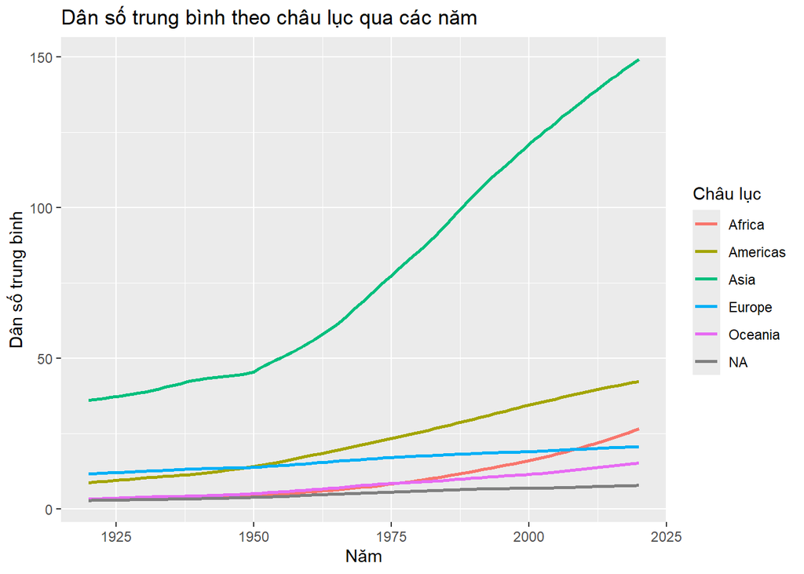

```r
ggplot(pop_mean, aes(x = year, y = pop_mean, color = continent)) +
  geom_line(linewidth = 1) +
  labs(
    title = "Dân số trung bình theo châu lục qua các năm",
    x = "Năm",
    y = "Dân số trung bình",
    color = "Châu lục"
  )
```

```r
ggsave("Bieudodansotbchauluc.png")
```

### Câu 12 - summarize

- Tính tuổi thọ trung bình theo châu lục và năm. Kết quả gồm 3 cột `continent`, `year`, và `lifeExp`.

```r
lifeExp_mean <- gap %>%
  group_by(continent, year) %>%
  summarise(
    lifeExp = mean(lifeExp, na.rm = TRUE),
    .groups = "drop"
  )

head(lifeExp_mean)
```

```
## # A tibble: 6 × 3
##   continent  year lifeExp
##   <chr>     <int>   <dbl>
## 1 Africa     1920    34.1
## 2 Africa     1921    34.0
## 3 Africa     1922    34.1
## 4 Africa     1923    34.4
## 5 Africa     1924    34.4
## 6 Africa     1925    34.5
```

### Câu 13 - facet_grid

- Vẽ biểu đồ đường để thể hiện sự thay đổi về tuổi thọ trung bình ở các châu lục theo thời gian, faceted theo châu lục (mỗi châu lục nằm trên một dòng - một cột, nhiều dòng).

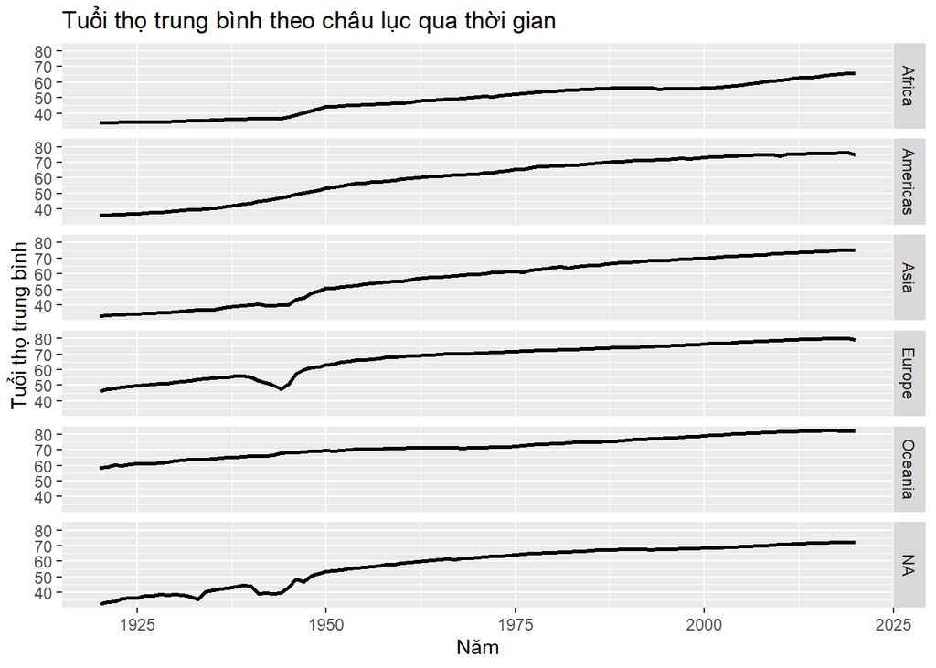

```r
ggplot(lifeExp_mean, aes(x = year, y = lifeExp)) +
  geom_line(linewidth = 1) +
  facet_grid(continent ~ .) +
  labs(
    title = "Tuổi thọ trung bình theo châu lục qua thời gian",
    x = "Năm",
    y = "Tuổi thọ trung bình"
  )
```

```r
ggsave("Bieudotuoithotb.png")
```

### Câu 14 - facet_grid

- Vẽ biểu đồ đường để thể hiện sự thay đổi về tuổi thọ trung bình ở các châu lục theo thời gian, faceted theo châu lục (tất cả các châu lục nằm trên một dòng - một dòng, nhiều cột).

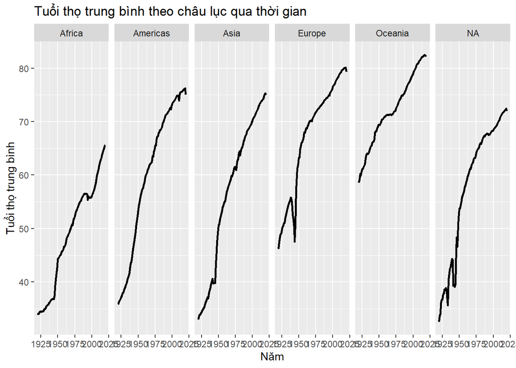

```r
ggplot(lifeExp_mean, aes(x = year, y = lifeExp)) +
  geom_line(linewidth = 1) +
  facet_grid(. ~ continent) +
  labs(
    title = "Tuổi thọ trung bình theo châu lục qua thời gian",
    x = "Năm",
    y = "Tuổi thọ trung bình"
  )
```

### Câu 15 - facet_wrap

- Vẽ biểu đồ đường để thể hiện sự thay đổi về tuổi thọ trung bình ở các châu lục theo thời gian, faceted theo châu lục (các châu lục nằm trên nhiều dòng, nhiều cột).

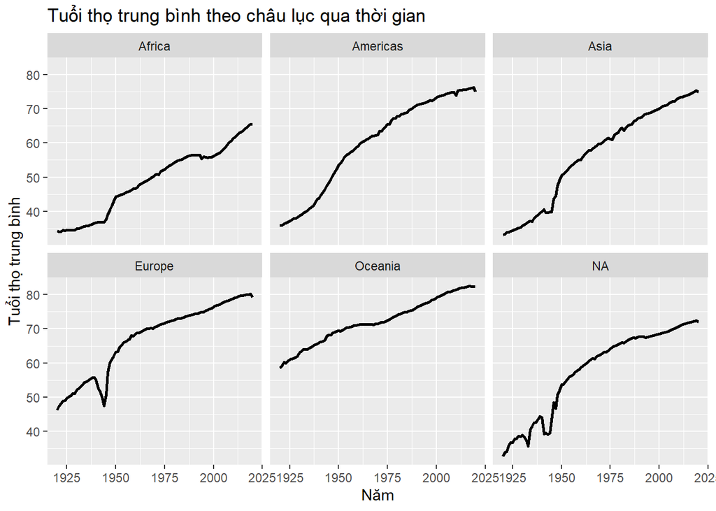

```r
ggplot(lifeExp_mean, aes(x = year, y = lifeExp)) +
  geom_line(linewidth = 1) +
  facet_wrap(~ continent) +
  labs(
    title = "Tuổi thọ trung bình theo châu lục qua thời gian",
    x = "Năm",
    y = "Tuổi thọ trung bình"
  )
```

### Câu 16 - geom_smooth

- Vẽ biểu đồ scatter để thể hiện mối quan hệ giữa GDP và tuổi thọ trung bình ở các quốc gia trong năm 2018, thêm smoother với tham số `method = "loess"` (mặc định) vào biểu đồ scatter. Thay đổi tham số `method = "lm"` để xem sự khác biệt. Điều chỉnh các tham số `se`, `span`, `level` để tùy biến biểu đồ. Dùng `?geom_smooth` để xem hướng dẫn về hàm `geom_smooth()`.

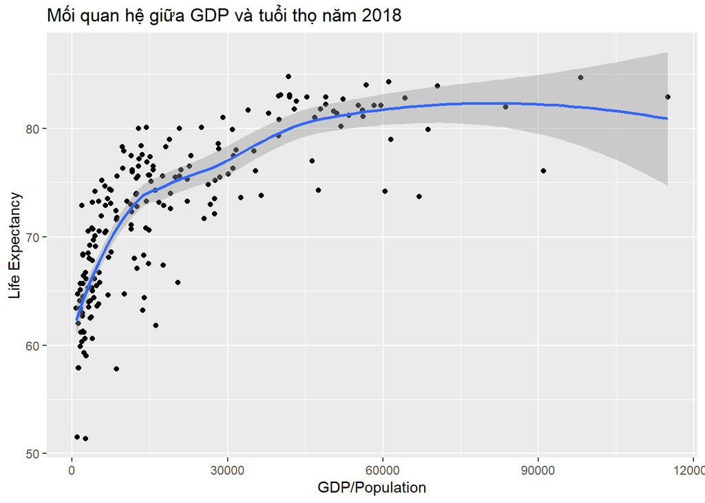

```r
ggplot(gm18, aes(x = gdpPercap, y = lifeExp)) +
  geom_point() +
  geom_smooth(method = "loess", se = TRUE, span = 0.8, level = 0.95) +
  labs(
    title = "Mối quan hệ giữa GDP và tuổi thọ năm 2018",
    x = "GDP/Population",
    y = "Life Expectancy"
  )
```

```r
ggsave("BieudoGDP&tuoitho.png")
```

### Câu 17 - facet_wrap

Thực hiện yêu cầu tương tự câu 16 nhưng faceted theo châu lục dùng `facet_wrap`.

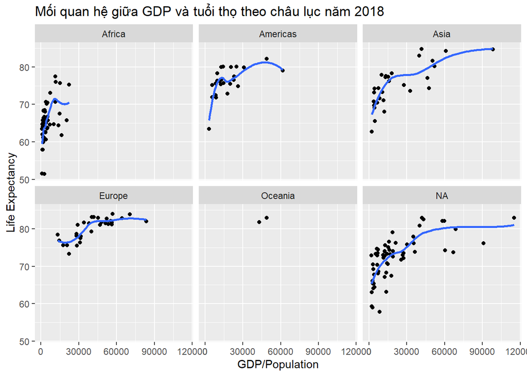

```r
ggplot(gm18, aes(x = gdpPercap, y = lifeExp)) +
  geom_point() +
  geom_smooth(method = "loess", se = FALSE) +
  facet_wrap(~ continent) +
  labs(
    title = "Mối quan hệ giữa GDP và tuổi thọ theo châu lục năm 2018",
    x = "GDP/Population",
    y = "Life Expectancy"
  )
```

```r
ggsave("BieudoGDP&tuoithofacet_wrap.png")
```

### Câu 18 - scale

- Vẽ biểu đồ scatter để thể hiện mối quan hệ giữa GDP và tuổi thọ trung bình ở các quốc gia trong năm 2018, scale GPD theo `log10`, scale tuổi thọ dùng `scale_x_continuous` hoặc `scale_y_continuous` với tham số `limits = c(0,90)`. Dùng `?scale_x_continuous` để xem hướng dẫn về các hàm scale.

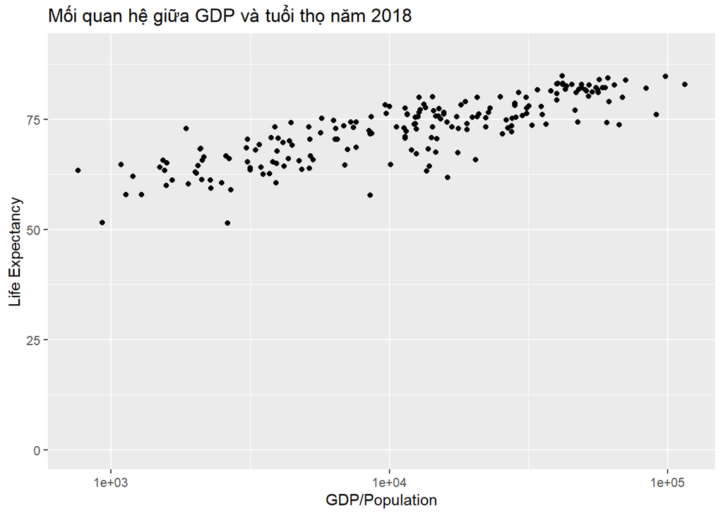

```r
ggplot(gm18, aes(x = gdpPercap, y = lifeExp)) +
  geom_point() +
  scale_x_log10() +
  scale_y_continuous(limits = c(0, 90)) +
  labs(
    title = "Mối quan hệ giữa GDP và tuổi thọ năm 2018",
    x = "GDP/Population",
    y = "Life Expectancy"
  )
```

```r
ggsave("BieudoGDP.png")
```

### Câu 19 - theme, labs

- Vẽ biểu đồ scatter để thể hiện mối quan hệ giữa GDP và tuổi thọ trung bình ở các quốc gia trong năm 2018, scale GPD theo `log10`, scale tuổi thọ dùng `scale_x_continuous` hoặc `scale_y_continuous` với tham số `limits = c(0,90)`. Dùng theme `theme_light()` và thêm các tiêu đề cho biểu đồ: tiêu đề cho trục `x` là “GDP/Population”, tiêu đề cho trục `y` là “Life Expectancy”, tiêu đề của biểu đồ là “2018 Life Expectancy and GDP”.

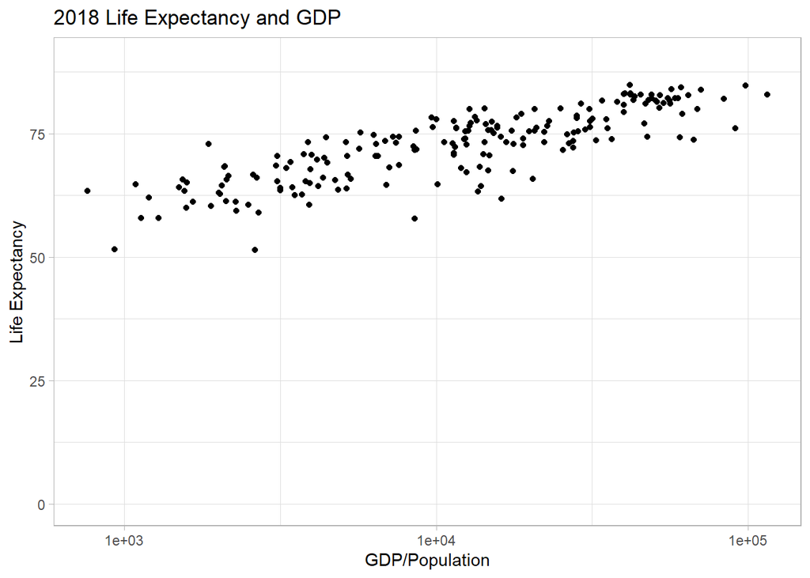

```r
ggplot(gm18, aes(x = gdpPercap, y = lifeExp)) +
  geom_point() +
  scale_x_log10() +
  scale_y_continuous(limits = c(0, 90)) +
  theme_light() +
  labs(
    title = "2018 Life Expectancy and GDP",
    x = "GDP/Population",
    y = "Life Expectancy"
  )
```

```r
ggsave("Bieudoscatter.png")
```